# Instructor Notes 2: Exploratory Data Analysis I

Let’s take an even more extreme case, where I have a categorial variable with 500 levels and I try to make a barplot (I will use `coord_flip` from the start since I already know this one is going to be even more crowded than the last one):

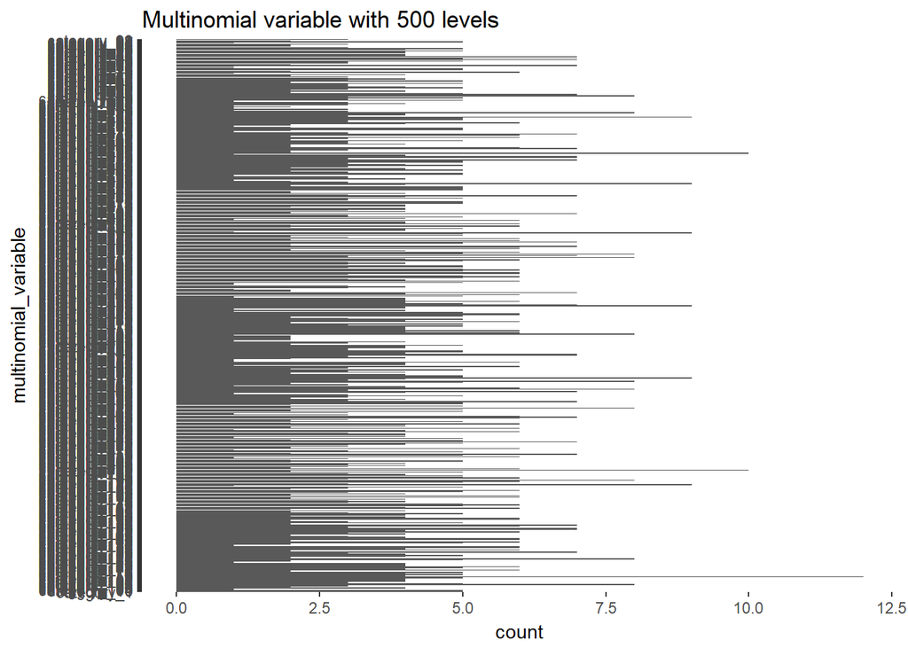

```r
# Simulate 1000 categorical data points with 500 possible levels
df <- data.frame(multinomial_variable = sample(paste0('category_', 1:500), 2000, replace=TRUE))

# Plot
ggplot(df, aes(x=multinomial_variable)) + geom_bar() +
  ggtitle('Multinomial variable with 500 levels') + coord_flip()
```

Yikes, this is a terrible plot because you cannot see any of the labels, even with the coordinates flipped. We could try making the labels smaller, but they would be too small to see. In this case, my recommendation is to make an entirely different plot: a histogram of the *counts* of each category, which you can do like this:

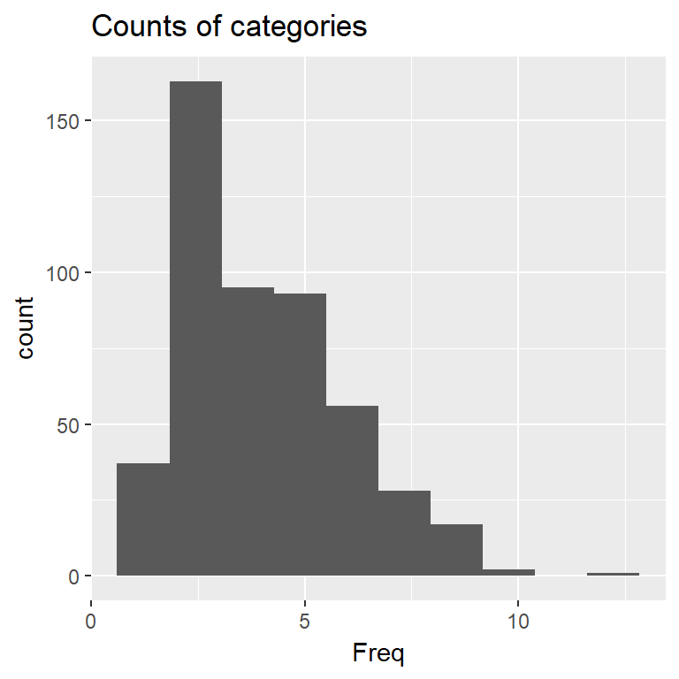

```r
# Create dataframe with counts of the categories
multinomial_variable_counts <- df$multinomial_variable %>% table
df_counts <- data.frame(multinomial_variable_counts)

# Plot
ggplot(df_counts, aes(x=Freq)) + geom_histogram(bins=10) +
  ggtitle('Counts of categories')
```

The plot above shows that most of the categories occur fewer than 5 times, while a few categories occur 10+ times. In other words, most of the categories are pretty rare, and no categories are dominating the dataset. You can’t see the individual categories, but when you have such an overwhelming number of categories, your goal should be to get an idea of how your data are distributed across the categories, and whether some categories are extremely common or extremely rare.

You might be wondering… how can we find out which are the most common categories? Unfortunately, the histogram above doesn’t show counts for individual categories. What you can do is print out a `table` of the categories and sort them to see which are the top categories, like this:

```r
# Print a table with the top 10 most common categories
df$multinomial_variable %>% table %>% sort(decreasing=TRUE) %>% head(10)
```

```
## .
## category_110   category_2 category_455 category_188 category_273
##           12           10           10            9            9
## category_332 category_391 category_430 category_486 category_104
##            9            9            9            9            8
```

We can also turn this table into a new dataframe and plot a barplot with only the top 10 most common categories:

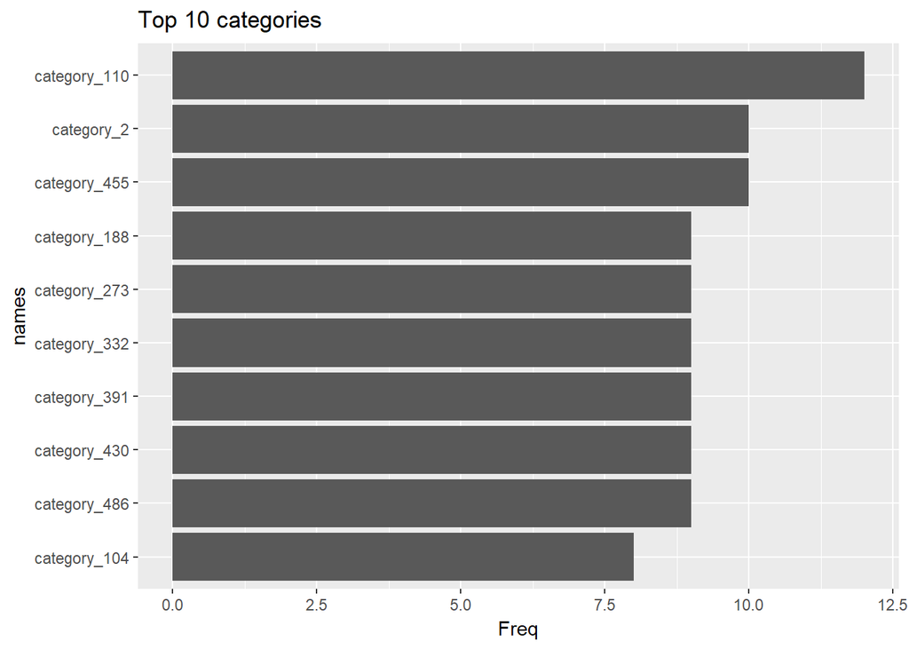

```r
# Create dataframe with counts of top 10 categories only
top_10_categories <- df$multinomial_variable %>% table %>% sort(decreasing=TRUE) %>% head(10)
df_top10 <- data.frame(names=names(top_10_categories), top_10_categories)

# Define factor levels to put them in order of frequency
df_top10$names <- factor(df_top10$names, levels=rev(names(top_10_categories)))

# Plot
ggplot(df_top10, aes(y=Freq, x=names)) + geom_bar(stat='identity') + coord_flip() +
  ggtitle('Top 10 categories')
```

Later in the course, we will talk more about how to handle categories with too many levels, because they present a challenge for modeling. Each category becomes a separate predictor variable in your model, so even though it is just a single column of data, it actually adds an enormous amount of complexity, which makes results difficult to interpret and can have an adverse effect on predictive performance.

### Binary variables

Binary variables are the easiest. In fact, they are so simple, I think it is overkill to make a barplot. You can simply use the `table` function to show counts:

```r
# Simulate random set of cats of dogs
x <- sample(c('cat','dog'), 100, replace=TRUE)

# Display a table counting the number of cats and dogs
table(x)
```

```
## x
## cat dog
##  51  49
```

There isn’t much else to say about binary variables for now. Let’s move on to a very common problem that plagues all variable types: missing data!

### Missing data

Models don’t know what to do with missing data, so we have to decide how to handle them. Although some model functions may silently handle missing data, usually by dropping entire rows that contain even one `NA` value, it is best practice to explicitly handle missing data in whatever way you think is most appropriate for your situation. Too often, people put missing data into a model and don’t realize how the model is handling those data points.

Although I saved this for the end of the lesson, I recommend checking for missing values at the start of your analysis, even before making any plots. This way, you will be aware from the beginning that there are missing values to replace. Conveniently, the `summary` function will show you how many `NA` values are in each column (which is another reason to use this function at the top of your script after you import the data!):

```r
# Simulate dataframe with 100 rows and 4 columns, one per variable type
n <- 100
df <- data.frame(continuous_var = rnorm(n),
                 ordinal_var = sample(1:5, n, replace=TRUE),
                 multinomial_var = sample(c('cat','dog','pig'), n, replace=TRUE),
                 binary_var = sample(0:1, n, replace=TRUE))

# Add one missing value to each column
df[1, 1] <- df[10, 2] <- df[50, 3] <- df[75, 4] <- NA

# Print table that counts the missing values per column
df %>% summary
```

```
##  continuous_var      ordinal_var    multinomial_var   binary_var
##  Min.   :-2.19076   Min.   :1.000   cat :39         Min.   :0.0000
##  1st Qu.:-0.63254   1st Qu.:2.000   dog :32         1st Qu.:0.0000
##  Median :-0.06202   Median :3.000   pig :28         Median :0.0000
##  Mean   :-0.01540   Mean   :2.909   NA's: 1         Mean   :0.4545
##  3rd Qu.: 0.53101   3rd Qu.:4.000                   3rd Qu.:1.0000
##  Max.   : 2.47493   Max.   :5.000                   Max.   :1.0000
##  NA's   :1          NA's   :1                       NA's   :1
```

There are two ways to handle missing data: you can drop rows with missing values, or you can replace the missing values with a reasonable alternative. Generally, replacing the missing data is better than dropping rows, unless there is something truly pathological about that entire row of data. In many cases, you want to keep the information in the other columns rather than throw away everything in the row.

So what should you replace the missing values with? As you can probably guess, it depends on the variable type! The most common and easy way to replace missing data is by using an appropriate measure of the [central tendency](https://en.wikipedia.org/wiki/Central_tendency) of the variable:

- For continuous variables, I recommend using the median. When a distribution is perfectly symmetrical, as in the case of a normal distribution, the mean and median will be identical. However, when you have a skewed variable or outliers, the mean will be biased in the direction of the rare values, and the median provides a better measure of central tendancy. Because it is robust to outliers and skew, the median is known as a [robust estimator](https://en.wikipedia.org/wiki/Robust_measures_of_scale) of central tendancy.
- For discrete variables (including ordinal, multinomial, and binary) use the mode.

```r
# If NA, replace with the median, otherwise leave it the same
df$continuous_var <- ifelse(is.na(df$continuous_var),
                            median(df$continuous_var, na.rm=TRUE),
                            df$continuous_var)

# If NA, replace with the mode, otherwise leave it the same
df$ordinal_var <- ifelse(is.na(df$ordinal_var),
                            mode(df$ordinal_var),
                            df$ordinal_var)
df$multinomial_var <- ifelse(is.na(df$multinomial_var),
                            mode(df$multinomial_var),
                            df$multinomial_var)
df$binary_var <- ifelse(is.na(df$binary_var),
                            mode(df$binary_var),
                            df$binary_var)

# Check to confirm the missing values are replaced
df %>% is.na %>% colSums
```

```
##  continuous_var     ordinal_var multinomial_var      binary_var
##               0               0               0               0
```

Great, that fixed the missing values. Note the use of the `na.rm=TRUE` argument in the `median` function. This is critical because if you do not include that argument, you will get an error trying to compute the median since it doesn’t know how to handle the `NA`.

Earlier, I mentioned that outliers can be dealt with in the same way as missing values. You can use an `ifelse` statement to replace any value that is larger than some threshold with the median. For example, the following line of code would replace any value that is outside 5 standard deviations with the median value, otherwise it keeps them the same:

`ifelse(abs(df$var) > 5*sd(df$var), median(df$var, na.rm=TRUE), df$var)`

A final suggestion is to always check for missing values again at the END of your data cleaning. People sometimes introduce `NA` values by accident during data cleaning steps. For instance, a common mistake is to log transform zeroes or negative values, which will silently get converted into `NA`. Best practice is to make one final check for `NA` in your data before diving into modeling.

# Concluding remarks

ITI is an iterative process that you will return to again and again on a given project, like an artist who keeps returning to your drawing, refining features a little bit more each time.

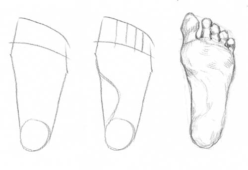

The image on the left is an artist’s cartoon ‘model’ of a foot, but it is barely recognizable as a foot. With each iteration of the drawing, the foot becomes more detailed. By the final drawing, it is obviously a foot. Part of keeping your motivation high during data science projects is to manage expectations. Your first draft may look like the foot on the left, not the foot on the right, and that is okay because we aren’t finished yet! Be patient and trust the process.